## Laboratorio 3 - Bruno Mitio A. Silva

# Questoees iniciais

```r
library(nycflights13)
library(dplyr)
library(magrittr)
tbl_df(flights)
```

```
## Source: local data frame [336,776 x 16]
##
##     year month   day dep_time dep_delay arr_time arr_delay carrier tailnum
##    (int) (int) (int)    (int)     (dbl)    (int)     (dbl)   (chr)   (chr)
## 1   2013     1     1      517         2      830        11      UA  N14228
## 2   2013     1     1      533         4      850        20      UA  N24211
## 3   2013     1     1      542         2      923        33      AA  N619AA
## 4   2013     1     1      544        -1     1004       -18      B6  N804JB
## 5   2013     1     1      554        -6      812       -25      DL  N668DN
## 6   2013     1     1      554        -4      740        12      UA  N39463
## 7   2013     1     1      555        -5      913        19      B6  N516JB
## 8   2013     1     1      557        -3      709       -14      EV  N829AS
## 9   2013     1     1      557        -3      838        -8      B6  N593JB
## 10  2013     1     1      558        -2      753         8      AA  N3ALAA
## ..   ...   ...   ...      ...       ...      ...       ...     ...     ...
## Variables not shown: flight (int), origin (chr), dest (chr), air_time
##   (dbl), distance (dbl), hour (dbl), minute (dbl)
```

```r
library(tidyr)
library(boot)
```

- filter

Atribua a uma tabela apenas os voos de janeiro de 2013.

Atribua a uma tabela apenas os voos de janeiro ou fevereiro de 2013.

Atribua a uma tabela apenas os voos com distancia maior do que 1000 milhas.

```r
fil1 <- flights %>%
  filter(year=='2013')
tbl_df(fil1)
```

```
## Source: local data frame [336,776 x 16]
##
##     year month   day dep_time dep_delay arr_time arr_delay carrier tailnum
##    (int) (int) (int)    (int)     (dbl)    (int)     (dbl)   (chr)   (chr)
## 1   2013     1     1      517         2      830        11      UA  N14228
## 2   2013     1     1      533         4      850        20      UA  N24211
## 3   2013     1     1      542         2      923        33      AA  N619AA
## 4   2013     1     1      544        -1     1004       -18      B6  N804JB
## 5   2013     1     1      554        -6      812       -25      DL  N668DN
## 6   2013     1     1      554        -4      740        12      UA  N39463
## 7   2013     1     1      555        -5      913        19      B6  N516JB
## 8   2013     1     1      557        -3      709       -14      EV  N829AS
## 9   2013     1     1      557        -3      838        -8      B6  N593JB
## 10  2013     1     1      558        -2      753         8      AA  N3ALAA
## ..   ...   ...   ...      ...       ...      ...       ...     ...     ...
## Variables not shown: flight (int), origin (chr), dest (chr), air_time
##   (dbl), distance (dbl), hour (dbl), minute (dbl)
```

```r
fil2 <- flights %>%
  filter((year=='2013'& month==1)|(year=='2013'& month==2))
tbl_df(fil2)
```

```
## Source: local data frame [51,955 x 16]
##
##     year month   day dep_time dep_delay arr_time arr_delay carrier tailnum
##    (int) (int) (int)    (int)     (dbl)    (int)     (dbl)   (chr)   (chr)
## 1   2013     1     1      517         2      830        11      UA  N14228
## 2   2013     1     1      533         4      850        20      UA  N24211
## 3   2013     1     1      542         2      923        33      AA  N619AA
## 4   2013     1     1      544        -1     1004       -18      B6  N804JB
## 5   2013     1     1      554        -6      812       -25      DL  N668DN
## 6   2013     1     1      554        -4      740        12      UA  N39463
## 7   2013     1     1      555        -5      913        19      B6  N516JB
## 8   2013     1     1      557        -3      709       -14      EV  N829AS
## 9   2013     1     1      557        -3      838        -8      B6  N593JB
## 10  2013     1     1      558        -2      753         8      AA  N3ALAA
## ..   ...   ...   ...      ...       ...      ...       ...     ...     ...
## Variables not shown: flight (int), origin (chr), dest (chr), air_time
##   (dbl), distance (dbl), hour (dbl), minute (dbl)
```

```r
fil3 <- flights %>%
  filter(distance>1000)
tbl_df(fil3)
```

```
## Source: local data frame [147,105 x 16]
##
##     year month   day dep_time dep_delay arr_time arr_delay carrier tailnum
##    (int) (int) (int)    (int)     (dbl)    (int)     (dbl)   (chr)   (chr)
## 1   2013     1     1      517         2      830        11      UA  N14228
## 2   2013     1     1      533         4      850        20      UA  N24211
## 3   2013     1     1      542         2      923        33      AA  N619AA
## 4   2013     1     1      544        -1     1004       -18      B6  N804JB
## 5   2013     1     1      555        -5      913        19      B6  N516JB
## 6   2013     1     1      558        -2      849        -2      B6  N793JB
## 7   2013     1     1      558        -2      853        -3      B6  N657JB
## 8   2013     1     1      558        -2      924         7      UA  N29129
## 9   2013     1     1      558        -2      923       -14      UA  N53441
## 10  2013     1     1      559        -1      941        31      AA  N3DUAA
## ..   ...   ...   ...      ...       ...      ...       ...     ...     ...
## Variables not shown: flight (int), origin (chr), dest (chr), air_time
##   (dbl), distance (dbl), hour (dbl), minute (dbl)
```

- select

Atribua a uma tabela apenas as colunas month e dep_delay.

Atribua a uma tabela apenas as colunas month e dep_delay, os nomes dessas colunas devem ser mese atraso.

Retire da tabela as colunas tailnum, origin e dest

```r
sel1 <- flights %>%
  select(month, dep_delay)
tbl_df(sel1)
```

```
## Source: local data frame [336,776 x 2]
##
##    month dep_delay
##    (int)     (dbl)
## 1      1         2
## 2      1         4
## 3      1         2
## 4      1        -1
## 5      1        -6
## 6      1        -4
## 7      1        -5
## 8      1        -3
## 9      1        -3
## 10     1        -2
## ..   ...       ...
```

```r
sel2 <- flights %>%
  select(mes = month, atraso = dep_delay)
tbl_df(sel2)
```

```
## Source: local data frame [336,776 x 2]
##
##      mes atraso
##    (int)  (dbl)
## 1      1      2
## 2      1      4
## 3      1      2
## 4      1     -1
## 5      1     -6
## 6      1     -4
## 7      1     -5
## 8      1     -3
## 9      1     -3
## 10     1     -2
## ..   ...    ...
```

```r
sel2 <- flights %>%
  select(-tailnum, -origin, -dest)
tbl_df(sel2)
```

```
## Source: local data frame [336,776 x 13]
##
##     year month   day dep_time dep_delay arr_time arr_delay carrier flight
##    (int) (int) (int)    (int)     (dbl)    (int)     (dbl)   (chr)  (int)
## 1   2013     1     1      517         2      830        11      UA   1545
## 2   2013     1     1      533         4      850        20      UA   1714
## 3   2013     1     1      542         2      923        33      AA   1141
## 4   2013     1     1      544        -1     1004       -18      B6    725
## 5   2013     1     1      554        -6      812       -25      DL    461
## 6   2013     1     1      554        -4      740        12      UA   1696
## 7   2013     1     1      555        -5      913        19      B6    507
## 8   2013     1     1      557        -3      709       -14      EV   5708
## 9   2013     1     1      557        -3      838        -8      B6     79
## 10  2013     1     1      558        -2      753         8      AA    301
## ..   ...   ...   ...      ...       ...      ...       ...     ...    ...
## Variables not shown: air_time (dbl), distance (dbl), hour (dbl), minute
##   (dbl)
```

- mutate

Calcule as colunas ganho_de_tempo que e dado por dep_delay - arr_delay e velocidade dada por distance / air_time * 60.

Calcule o horario de chegada considerando as colunas hour, minute e air_time.

A tabela deve conter duas colunas novas: hour2 com a hora de chegada e minute2 com o minuto de chegada.

```r
mut1 <- flights %>%
  mutate(ganho_de_tempo = dep_delay - arr_delay,
         velocidade = distance / air_time*60)
tbl_df(mut1)
```

```
## Source: local data frame [336,776 x 18]
##
##     year month   day dep_time dep_delay arr_time arr_delay carrier tailnum
##    (int) (int) (int)    (int)     (dbl)    (int)     (dbl)   (chr)   (chr)
## 1   2013     1     1      517         2      830        11      UA  N14228
## 2   2013     1     1      533         4      850        20      UA  N24211
## 3   2013     1     1      542         2      923        33      AA  N619AA
## 4   2013     1     1      544        -1     1004       -18      B6  N804JB
## 5   2013     1     1      554        -6      812       -25      DL  N668DN
## 6   2013     1     1      554        -4      740        12      UA  N39463
## 7   2013     1     1      555        -5      913        19      B6  N516JB
## 8   2013     1     1      557        -3      709       -14      EV  N829AS
## 9   2013     1     1      557        -3      838        -8      B6  N593JB
## 10  2013     1     1      558        -2      753         8      AA  N3ALAA
## ..   ...   ...   ...      ...       ...      ...       ...     ...     ...
## Variables not shown: flight (int), origin (chr), dest (chr), air_time
##   (dbl), distance (dbl), hour (dbl), minute (dbl), ganho_de_tempo (dbl),
##   velocidade (dbl)
```

```r
mut2 <- flights %>%
  mutate(hour2 = round(hour + air_time/60),
         minute2 = minute + (air_time/60) - round(air_time/60))

mut2a <- mut2 %>%
  filter(hour2 > 24) %>%
  mutate(hour2 = hour2 - 24)

mut2b <- mut2 %>%
  filter(hour2 <= 24)

mut2 <- rbind(mut2a,mut2b)
tbl_df(mut2)
```

```
## Source: local data frame [327,346 x 18]
##
##     year month   day dep_time dep_delay arr_time arr_delay carrier tailnum
##    (int) (int) (int)    (int)     (dbl)    (int)     (dbl)   (chr)   (chr)
## 1   2013     1     1     1905         5     2311        10      DL  N727TW
## 2   2013     1     1     1915        11     2242        -4      UA  N76503
## 3   2013     1     1     1923        24     2239         5      B6  N552JB
## 4   2013     1     1     1925        25     2259        21      DL  N624AG
## 5   2013     1     1     1930       105     2233        81      DL  N3764D
## 6   2013     1     1     1937        32     2250        25      AA  N327AA
## 7   2013     1     1     1952        -8     2314       -11      VX  N640VA
## 8   2013     1     1     1952        22     2257         6      UA  N76523
## 9   2013     1     1     1957        12     2307       -22      B6  N652JB
## 10  2013     1     1     2024       109     2328        91      B6  N607JB
## ..   ...   ...   ...      ...       ...      ...       ...     ...     ...
## Variables not shown: flight (int), origin (chr), dest (chr), air_time
##   (dbl), distance (dbl), hour (dbl), minute (dbl), hour2 (dbl), minute2
##   (dbl)
```

- summarise

Calcule a media da distancia de todos os voos.

Calcule a media da distancia dos voos por mes

Calcule a media, mediana, primeiro quartil e terceiro quartil do tempo de viagem por mes.

```r
summ1 <- flights %>%
  summarise(media = mean(distance))
summ1
```

```
## Source: local data frame [1 x 1]
##
##      media
##      (dbl)
## 1 1039.913
```

```r
summ2 <- flights %>%
  group_by(month) %>%
  summarise(media = mean(distance))
summ2
```

```
## Source: local data frame [12 x 2]
##
##    month    media
##    (int)    (dbl)
## 1      1 1006.844
## 2      2 1000.982
## 3      3 1011.987
## 4      4 1038.733
## 5      5 1040.913
## 6      6 1057.125
## 7      7 1058.596
## 8      8 1062.138
## 9      9 1041.250
## 10    10 1038.876
## 11    11 1050.305
## 12    12 1064.656
```

```r
summ3 <- flights %>%
  group_by(month) %>%
  summarise(media = mean(distance),
            mediana = median(distance),
            q1 = quantile(distance,probs =0.25),
            q3 = quantile(distance, probs = 0.75))
summ3
```

```
## Source: local data frame [12 x 5]
##
##    month    media mediana    q1    q3
##    (int)    (dbl)   (dbl) (dbl) (dbl)
## 1      1 1006.844     872   483  1372
## 2      2 1000.982     872   488  1372
## 3      3 1011.987     888   502  1372
## 4      4 1038.733     888   509  1389
## 5      5 1040.913     820   502  1389
## 6      6 1057.125     872   502  1400
## 7      7 1058.596     872   509  1400
## 8      8 1062.138     872   509  1400
## 9      9 1041.250     764   502  1389
## 10    10 1038.876     812   502  1389
## 11    11 1050.305     888   529  1389
## 12    12 1064.656     944   533  1400
```

- arrange

Ordene a base de dados pelo atraso na partida em ordem crescente.

Repita a questao anterior, porem na ordem decrescente.

```r
arr1 <- flights %>%
  select(year, month, origin, dest, distance) %>%
  arrange(distance)
tbl_df(arr1)
```

```
## Source: local data frame [336,776 x 5]
##
##     year month origin  dest distance
##    (int) (int)  (chr) (chr)    (dbl)
## 1   2013     7    EWR   LGA       17
## 2   2013     1    EWR   PHL       80
## 3   2013     1    EWR   PHL       80
## 4   2013     1    EWR   PHL       80
## 5   2013     1    EWR   PHL       80
## 6   2013     1    EWR   PHL       80
## 7   2013     1    EWR   PHL       80
## 8   2013     1    EWR   PHL       80
## 9   2013     1    EWR   PHL       80
## 10  2013     1    EWR   PHL       80
## ..   ...   ...    ...   ...      ...
```

```r
arr2 <- flights %>%
  select(year, month, origin, dest, distance) %>%
  arrange(desc(distance))
tbl_df(arr2)
```

```
## Source: local data frame [336,776 x 5]
##
##     year month origin  dest distance
##    (int) (int)  (chr) (chr)    (dbl)
## 1   2013     1    JFK   HNL     4983
## 2   2013     1    JFK   HNL     4983
## 3   2013     1    JFK   HNL     4983
## 4   2013     1    JFK   HNL     4983
## 5   2013     1    JFK   HNL     4983
## 6   2013     1    JFK   HNL     4983
## 7   2013     1    JFK   HNL     4983
## 8   2013     1    JFK   HNL     4983
## 9   2013     1    JFK   HNL     4983
## 10  2013     1    JFK   HNL     4983
## ..   ...   ...    ...   ...      ...
```

- spread

Crie uma tabela em que cada linha é um dia e cada coluna é o atraso médio de partida por mês.

Repita a mesma operação, mas dessa vez cada coluna será uma hora do dia.

```r
spr1<- flights %>%
  group_by(day, month) %>%
  summarise(media_dia = mean(dep_delay, na.rm = T)) %>%
  ungroup() %>%
  spread(month, media_dia)
tbl_df(spr1)
```

```
## Source: local data frame [31 x 13]
##
##      day         1         2         3         4         5         6
##    (int)     (dbl)     (dbl)     (dbl)     (dbl)     (dbl)     (dbl)
## 1      1 11.548926 10.852909 11.015890 12.421436  2.903427  2.778220
## 2      2 13.858824  5.422059  8.026525  8.260204  6.388548 34.013366
## 3      3 10.987832  7.018868  6.065934  3.452525 14.181535 25.309698
## 4      4  8.951595 10.924078  4.753910  6.963265  8.820270  4.111925
## 5      5  5.732218  5.322727  5.018162  5.905102  4.577387  4.878756
## 6      6  7.148014  5.621501 21.012626  4.950521  7.595701  5.056760
## 7      7  5.417204  6.496767 20.370748  2.859031  2.107143 27.543290
## 8      8  2.553073 14.855895 83.536921  2.424305 43.217778  8.413212
## 9      9  2.276477 18.525773 11.276455  9.427083 20.713251  6.241722
## 10    10  2.844995 15.175592 10.733112 33.023675 11.491753 30.619450
## ..   ...       ...       ...       ...       ...       ...       ...
## Variables not shown: 7 (dbl), 8 (dbl), 9 (dbl), 10 (dbl), 11 (dbl), 12
##   (dbl)
```

```r
spr2<- flights %>%
  group_by(day, hour) %>%
  summarise(media = mean(dep_delay, na.rm = T)) %>%
  ungroup() %>%
  spread(day, media)
tbl_df(spr2)
```

```
## Source: local data frame [26 x 32]
##
##     hour           1           2           3           4           5
##    (dbl)       (dbl)       (dbl)       (dbl)       (dbl)       (dbl)
## 1      0 120.1428571 127.3870968  91.6000000  34.5000000 102.8823529
## 2      1 150.8750000 185.7142857 202.0000000 218.5000000 159.3333333
## 3      2          NA 324.0000000 156.0000000          NA          NA
## 4      3          NA 348.0000000          NA          NA          NA
## 5      4  -6.1000000  -6.5000000  -4.5714286  -6.0000000  -7.3000000
## 6      5  -4.5648536  -4.6205534  -4.4272727  -4.6800000  -4.7343750
## 7      6  -1.2801556  -1.1231190  -0.7758389  -2.1288265  -2.8013423
## 8      7   0.0204978   0.0877193  -0.3328551  -1.4588563   0.3703190
## 9      8   2.3417722   1.2875143   0.7042093  -0.1460177  -1.1078546
## 10     9   3.2826446   3.6177847   3.3799682   1.8754045   0.8689076
## ..   ...         ...         ...         ...         ...         ...
## Variables not shown: 6 (dbl), 7 (dbl), 8 (dbl), 9 (dbl), 10 (dbl), 11
##   (dbl), 12 (dbl), 13 (dbl), 14 (dbl), 15 (dbl), 16 (dbl), 17 (dbl), 18
##   (dbl), 19 (dbl), 20 (dbl), 21 (dbl), 22 (dbl), 23 (dbl), 24 (dbl), 25
##   (dbl), 26 (dbl), 27 (dbl), 28 (dbl), 29 (dbl), 30 (dbl), 31 (dbl)
```

- gather

Considerando as tabelas criadas nas perguntas sobre o spread, transforme-as em um formato tidy.

```r
gat1 <- spr1 %>%
  gather(month, day)
tbl_df(gat1)
```

```
## Source: local data frame [372 x 3]
##
##      day month       day
##    (int) (chr)     (dbl)
## 1      1     1 11.548926
## 2      2     1 13.858824
## 3      3     1 10.987832
## 4      4     1  8.951595
## 5      5     1  5.732218
## 6      6     1  7.148014
## 7      7     1  5.417204
## 8      8     1  2.553073
## 9      9     1  2.276477
## 10    10     1  2.844995
## ..   ...   ...       ...
```

# Desafios

- Atraso Total no Mes

Sumarise em uma tabela qual foi a média de atraso total e seu intervalo de confiança por mes, apenas considerando os voos que atrasaram

```r
atrasoMes1 <- flights %>%
  mutate( atrasoTot = dep_delay + arr_delay) %>%
  filter(atrasoTot >= 0) %>%
  group_by(month) %>%
  summarise(n = length(atrasoTot),
            media = mean(atrasoTot, na.rm = TRUE),
            desv = sd(atrasoTot, na.rm = TRUE),
            erro = qnorm(0.975) * desv / sqrt(n),
            IC0 = round(media - erro, 4),
            IC1 = round(media + erro, 4),
            IC = paste(IC0, "  -  ", IC1))
atrasoMes <- atrasoMes1 %>%
  select(mes = month, media, IC)
atrasoMes
```

```
## Source: local data frame [12 x 3]
##
##      mes    media                    IC
##    (int)    (dbl)                 (chr)
## 1      1 61.71704  59.944   -   63.4901
## 2      2 61.98728 60.1904   -   63.7842
## 3      3 74.09314 72.1932   -   75.9931
## 4      4 77.36766 75.4549   -   79.2804
## 5      5 76.42289 74.4765   -   78.3693
## 6      6 96.47957 94.3285   -   98.6307
## 7      7 96.28029 94.2136   -   98.3469
## 8      8 69.77547 68.0796   -   71.4713
## 9      9 70.01751 67.4271   -   72.6079
## 10    10 53.40882 51.7998   -   55.0178
## 11    11 48.84713 47.3272   -   50.3671
## 12    12 69.33448 67.7498   -   70.9192
```

- Maiores atrasos

Summarise em uma tabela quais foram os 10 destinos com mais viagens com atraso superior a 60 minutos. Considere o atraso total definido na pergunta anterior.

```r
atraso <- flights %>%
  group_by(dest) %>%
  summarise(viagens = length(dest),
            atrasoTotal = sum(dep_delay, arr_delay, na.rm = T))%>%
  filter(atrasoTotal > 60) %>%
  arrange(desc(atrasoTotal))
atraso<- atraso[1:10,1:3]
atraso
```

```
## Source: local data frame [10 x 3]
##
##     dest viagens atrasoTotal
##    (chr)   (int)       (dbl)
## 1    ATL   17215      401651
## 2    ORD   17283      323192
## 3    FLL   12055      248086
## 4    MCO   14082      233846
## 5    CLT   14064      226980
## 6    SFO   13331      205431
## 7    DCA    9705      176862
## 8    BOS   15508      175167
## 9    RDU    8163      175135
## 10   DEN    7266      170840
```

# Outras bases de dados reais

# Coalitions

```r
data(wto_data , package='abjutils')
data(wto_dyad_sample, package='abjutils')
tbl_df(wto_data)
```

```
## Source: local data frame [3,189 x 9]
##
##    ccode   cname leste_oeste norte_sul latitude longitude          pib
##    (int)   (chr)       (chr)     (chr)    (dbl)     (dbl)        (dbl)
## 1      8 Albania           E         N     41.0      20.0  11000000000
## 2      8 Albania           E         N     41.0      20.0  11000000000
## 3      8 Albania           E         N     41.0      20.0  12000000000
## 4      8 Albania           E         N     41.0      20.0  13000000000
## 5      8 Albania           E         N     41.0      20.0  14000000000
## 6      8 Albania           E         N     41.0      20.0  15000000000
## 7      8 Albania           E         N     41.0      20.0  16000000000
## 8      8 Albania           E         N     41.0      20.0 886698310107
## 9      8 Albania           E         N     41.0      20.0 865115528609
## 10    24  Angola           E         S    -12.5      18.5  20000000000
## ..   ...     ...         ...       ...      ...       ...          ...
## Variables not shown: pib_per_capita (dbl), democracia (dbl)
```

```r
str(wto_data)
```

```
## Classes 'tbl_df', 'tbl' and 'data.frame':    3189 obs. of  9 variables:
##  $ ccode         : int  8 8 8 8 8 8 8 8 8 24 ...
##  $ cname         : chr  "Albania" "Albania" "Albania" "Albania" ...
##  $ leste_oeste   : chr  "E" "E" "E" "E" ...
##  $ norte_sul     : chr  "N" "N" "N" "N" ...
##  $ latitude      : num  41 41 41 41 41 41 41 41 41 -12.5 ...
##  $ longitude     : num  20 20 20 20 20 20 20 20 20 18.5 ...
##  $ pib           : num  1.1e+10 1.1e+10 1.2e+10 1.3e+10 1.4e+10 ...
##  $ pib_per_capita: num  3177 3262 3305 3623 4016 ...
##  $ democracia    : num  1 1 1 1 1 1 1 1 1 0 ...
```

```r
tbl_df(wto_dyad_sample)
```

```
## Source: local data frame [28,008 x 5]
##
##    ccode1 ccode2 ccoalition   year coalition
##     (chr)  (chr)     (fctr) (fctr)     (dbl)
## 1     108    203         24   2000         0
## 2     288    840         34   2001         0
## 3      52     50         18   1986         0
## 4     270    454         65   1994         0
## 5     148    642         10   2004         0
## 6     340    392         15   1996         0
## 7     578    752         15   1983         0
## 8     400    360          5   2005         0
## 9     458    807         62   2006         0
## 10    192    246         52   1989         0
## ..    ...    ...        ...    ...       ...
```

```r
str(wto_dyad_sample)
```

```
## Classes 'tbl_df' and 'data.frame':   28008 obs. of  5 variables:
##  $ ccode1    : chr  "108" "288" "52" "270" ...
##  $ ccode2    : chr  "203" "840" "50" "454" ...
##  $ ccoalition: Factor w/ 61 levels "1","10","11",..: 16 25 9 53 2 7 7 39 51 41 ...
##  $ year      : Factor w/ 19 levels "1982","1983",..: 13 14 3 8 17 9 2 18 19 4 ...
##  $ coalition : num  0 0 0 0 0 0 0 0 0 0 ...
```

Qual e a unidade observacional (o que identifica uma observacao) na base wto_data?

R: Sao informacoes basicas de cada pais para um dado periodo do tempo.

Quantas coalizoes tivemos em cada ano?

```r
coal1 <- wto_dyad_sample %>%
  group_by(year)
sum(coal1$coalition)
```

```
## [1] 14004
```

Qual e o codigo do pais que entrou mais vezes em alguma coalizao?

```r
coal2a <- wto_dyad_sample %>%
  select(ccode = ccode1, ccoalition:coalition)
coal2b <- wto_dyad_sample %>%
  select(ccode = ccode2, ccoalition:coalition)
coal2 <- rbind(coal2a, coal2b)
coal2 <- coal2%>%
  group_by(ccode) %>%
  summarise(coalizoes = sum(coalition)) %>%
  arrange(desc(coalizoes))
coal2max <- coal2[1:1,1:2]
coal2max
```

```
## Source: local data frame [1 x 2]
##
##   ccode coalizoes
##   (chr)     (dbl)
## 1   356       427
```

Construa uma matriz de adjacencias usando dplyr e tidyr.

Obs: Como ficaria muito grande uma matriz com todos os anos e coalizoes, separamos uma matriz de adjacencias no ano de 2001 para as coalizoes de numero 54. A escolha foi feita por ser o ano e a coalizao com maiores ocorrencias de acordos.

```r
wto_adj <- wto_dyad_sample %>%
  filter(year==2001, ccoalition ==54, ccode2!=100) %>%
  select(ccode1, ccode2, coalition) %>%
  spread(ccode1, coalition)
wto_adj[is.na(wto_adj)]<- 0
linhas <- wto_adj$ccode2
wto_adj$ccode2 <- NULL
rownames(wto_adj) <- linhas

tbl_df(wto_adj)
```

```
## Source: local data frame [66 x 66]
##
##      108   120   124   140   144   148   178   180   192   204   212   214
##    (dbl) (dbl) (dbl) (dbl) (dbl) (dbl) (dbl) (dbl) (dbl) (dbl) (dbl) (dbl)
## 1      0     0     0     0     0     0     0     0     0     1     0     0
## 2      1     0     0     0     0     0     0     0     0     1     0     0
## 3      1     1     0     0     0     0     0     0     0     1     0     0
## 4      1     1     0     1     0     1     1     1     1     1     0     1
## 5      1     1     0     1     0     0     0     0     0     1     0     0
## 6      1     1     0     1     0     1     0     0     0     1     0     0
## 7      1     1     0     1     0     1     1     0     0     1     0     0
## 8      1     1     0     1     0     1     1     1     0     1     0     0
## 9      0     0     0     0     0     0     0     0     0     0     0     0
## 10     0     0     0     0     0     0     0     0     0     0     0     0
## ..   ...   ...   ...   ...   ...   ...   ...   ...   ...   ...   ...   ...
## Variables not shown: 218 (dbl), 24 (dbl), 250 (dbl), 262 (dbl), 266 (dbl),
##   270 (dbl), 288 (dbl), 324 (dbl), 332 (dbl), 340 (dbl), 348 (dbl), 356
##   (dbl), 360 (dbl), 380 (dbl), 384 (dbl), 388 (dbl), 404 (dbl), 426 (dbl),
##   440 (dbl), 450 (dbl), 454 (dbl), 466 (dbl), 478 (dbl), 480 (dbl), 50
##   (dbl), 504 (dbl), 508 (dbl), 516 (dbl), 52 (dbl), 562 (dbl), 566 (dbl),
##   586 (dbl), 600 (dbl), 604 (dbl), 608 (dbl), 624 (dbl), 646 (dbl), 68
##   (dbl), 686 (dbl), 694 (dbl), 703 (dbl), 710 (dbl), 716 (dbl), 72 (dbl),
##   748 (dbl), 76 (dbl), 764 (dbl), 768 (dbl), 788 (dbl), 800 (dbl), 818
##   (dbl), 834 (dbl), 854 (dbl), 894 (dbl)
```

```r
str(wto_adj)
```

```
## Classes 'tbl_df', 'tbl' and 'data.frame':    66 obs. of  66 variables:
##  $ 108: num  0 1 1 1 1 1 1 1 0 0 ...
##  $ 120: num  0 0 1 1 1 1 1 1 0 0 ...
##  $ 124: num  0 0 0 0 0 0 0 0 0 0 ...
##  $ 140: num  0 0 0 1 1 1 1 1 0 0 ...
##  $ 144: num  0 0 0 0 0 0 0 0 0 0 ...
##  $ 148: num  0 0 0 1 0 1 1 1 0 0 ...
##  $ 178: num  0 0 0 1 0 0 1 1 0 0 ...
##  $ 180: num  0 0 0 1 0 0 0 1 0 0 ...
##  $ 192: num  0 0 0 1 0 0 0 0 0 0 ...
##  $ 204: num  1 1 1 1 1 1 1 1 0 0 ...
##  $ 212: num  0 0 0 0 0 0 0 0 0 0 ...
##  $ 214: num  0 0 0 1 0 0 0 0 0 0 ...
##  $ 218: num  0 0 0 1 0 0 0 0 0 0 ...
##  $ 24 : num  1 1 1 1 1 1 1 1 0 1 ...
```

[output cut: 52 more lines]

# CARF

```r
data(carf, package='abjutils')
```

Quantos processos temos na base de dados?

```r
length(unique(carf$n_processo))
```

```
## [1] 48748
```

Construa uma tabela contendo o volume de acordaos em cada ano. Voce nota algum ano com comportamento estranho?

```r
carf1 <- carf %>%
  group_by(ano) %>%
  summarise(acordaos = length(id))
carf1
```

```
## Source: local data frame [27 x 2]
##
##      ano acordaos
##    (chr)    (int)
## 1   1986        2
## 2   1988        4
## 3   1989       28
## 4   1990       50
## 5   1991      328
## 6   1992      619
## 7   1993      566
## 8   1994      649
## 9   1995      639
## 10  1996      638
## ..   ...      ...
```

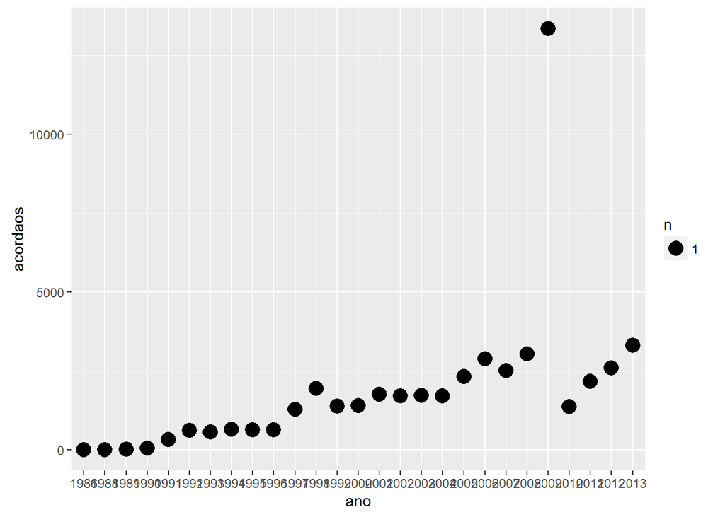

```r
library(ggplot2)

ggplot(carf1, aes(x = ano, y = acordaos))+
  geom_count()
```

R: Sim. Como e possivel observar na tabela e no grafico acima, 2009 foi um ano atipico (outlier).

Agora retire da base os acordaos que contem texto da decisao e texto da ementa vazios. Refaca a tabela e interprete.

```r
carf2 <- carf %>%
  filter(txt_ementa != "", txt_decisao !="") %>%
  group_by(ano) %>%
  summarise(acordaos = length(id))
carf2
```

```
## Source: local data frame [27 x 2]
##
##      ano acordaos
##    (chr)    (int)
## 1   1986        1
## 2   1988        1
## 3   1989        2
## 4   1990        5
## 5   1991       17
## 6   1992       12
## 7   1993       27
## 8   1994       33
## 9   1995       58
## 10  1996      164
## ..   ...      ...
```

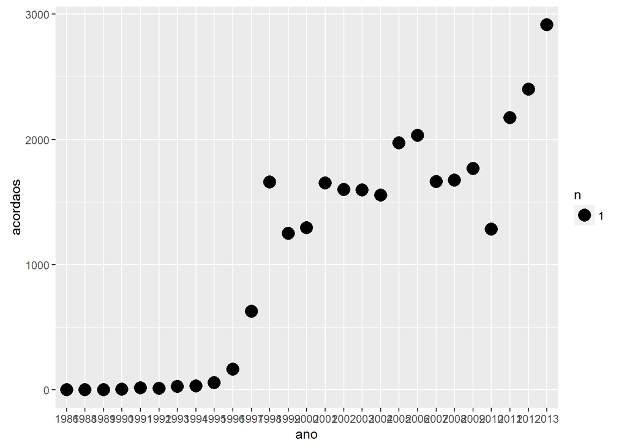

```r
ggplot(carf2, aes(x = ano, y = acordaos))+
  geom_count()
```

Quando eliminamos os acordaos que contenham texto da decisao e texto da ementa vazios, 2009 deixa de ser um ano outlier. Provavelmente, a maior parte do grande numero de acordaos em 2009 eram compostos por textos de decisao e emenda vazios.

Utilizando a funcao str_detect(), crie colunas (que valem TRUE ou FALSE)

```r
library(stringr)

carf3 <- carf %>%
  mutate(negar_provimento = str_detect(txt_decisao, "negar?(do)? (o )?provimento|negou se (o )?provimento|recurso nao provido"),
         dar_provimento = str_detect(txt_decisao, "dar?(do)? (o )?provimento|deu se (o )?provimento|recurso provido"),
         em_parte = str_detect(txt_decisao, "em parte|parcial"),
         diligencia = str_detect(txt_decisao, "diligencia"),
         nao_conhecer = str_detect(txt_decisao, "conhec"),
         anular = str_detect(txt_decisao,"nul(a|o|i)"))
tbl_df(carf3)
```

```
## Source: local data frame [50,000 x 15]
##
##        id           n_processo    n_decisao   ano       tipo_recurso
##     (int)                (chr)        (chr) (chr)              (chr)
## 1   33377   11050.000284/96-90    104-16093  1998 RECURSO VOLUNTARIO
## 2   59466 13063.000049/2001-69    104-19166  2002 RECURSO VOLUNTARIO
## 3   27312   10907.000641/96-66    103-19680  1998 RECURSO VOLUNTARIO
## 4  255416 10166.908059/2009-55 3403-002.259  2013 RECURSO VOLUNTARIO
## 5  214359   10980.004878/00-09    197-00118  2009 RECURSO VOLUNTARIO
## 6  121364 13888.003115/2005-82    104-22486  2007 RECURSO VOLUNTARIO
## 7   75520 13808.000175/2001-62    201-76854  2003 RECURSO VOLUNTARIO
## 8   50101   13702.000716/95-02    104-17328  2000  RECURSO DE OFÍCIO
## 9  132922 13830.001980/2004-79    105-17200  2008 RECURSO VOLUNTARIO
## 10   1155   10510.002333/90-51    202-04541  1991 RECURSO VOLUNTARIO
## ..    ...                  ...          ...   ...                ...
## Variables not shown: contribuinte (chr), relator (chr), txt_ementa (chr),
##   txt_decisao (chr), negar_provimento (lgl), dar_provimento (lgl),
##   em_parte (lgl), diligencia (lgl), nao_conhecer (lgl), anular (lgl)
```

Faca uma tabela mostrando a quantidade de acordaos em que foi dado provimento, negado provimento, etc. Considere somente os casos em que tipo_recurso foi recurso voluntario

```r
negar_provimento <- c(table(carf3$negar_provimento))
dar_provimento <- c(table(carf3$dar_provimento))
em_parte <- c(table(carf3$em_parte))
diligencia <- c(table(carf3$diligencia))
nao_conhecer <- c(table(carf3$nao_conhecer))
anular <- c(table(carf3$anular))

voluntario <- cbind(negar_provimento,dar_provimento,em_parte,diligencia,nao_conhecer,anular)
voluntario <- data.frame(voluntario)
voluntario <- t(voluntario)
voluntario
```

```
##                  FALSE TRUE
## negar_provimento 46649 3351
## dar_provimento   47036 2964
## em_parte         46095 3905
## diligencia       47799 2201
## nao_conhecer     47067 2933
## anular           47823 2177
```

# SABESP

```r
data(sabesp, package='abjutils')
sabesp <- sabesp
```

Descreva a base de dados.

O banco de dados “sabesp” reune, para cada dia da serie, a media historica de volume do reservatorio no mes; a pluviometria do dia e acumulada no mes; e o volume percentual do reservatorio no dia.

Crie uma tabela descritiva (media, desvio padrao, mediana, quartis, maximo, minimo) por mes, mostrando os lugares separadamente.

```r
sab1 <- sabesp %>%
  mutate(ano = substr(data, 1,4),
         dia = substr(data, 9,10),
         mes = substr(data, 6,7))

sab2 <- sab1 %>%
  select(lugar, mes, pluviometria_do_dia) %>%
  group_by(lugar, mes) %>%
  summarise(media_pluviometria = mean(pluviometria_do_dia),
            desvio_pluviometria = sd(pluviometria_do_dia),
            mediana_pluviometria = median(pluviometria_do_dia),
            q1 = quantile(pluviometria_do_dia,probs =0.25),
            q3 = quantile(pluviometria_do_dia, probs = 0.75),
            maximo_pluviometria = which.max(pluviometria_do_dia),
            minimo_pluviometria = which.min(pluviometria_do_dia))
sab2
```

```
## Source: local data frame [72 x 9]
## Groups: lugar [?]
##
##               lugar   mes media_pluviometria desvio_pluviometria
##               (chr) (chr)              (dbl)               (dbl)
## 1  sistemaAltoTiete    01          7.9418301           11.950719
## 2  sistemaAltoTiete    02          5.2923913            8.900614
## 3  sistemaAltoTiete    03          5.1586885           10.024260
## 4  sistemaAltoTiete    04          3.4663300            7.297932
## 5  sistemaAltoTiete    05          1.7977124            6.867211
## 6  sistemaAltoTiete    06          1.8473154            5.205612
## 7  sistemaAltoTiete    07          2.1701639            6.300558
## 8  sistemaAltoTiete    08          0.8143322            3.434445
## 9  sistemaAltoTiete    09          2.2110738            6.238118
## 10 sistemaAltoTiete    10          3.6937500            8.338855
## ..              ...   ...                ...                 ...
## Variables not shown: mediana_pluviometria (dbl), q1 (dbl), q3 (dbl),
##   maximo_pluviometria (int), minimo_pluviometria (int)
```

Construa uma tabela descritiva contendo a media, mediana, desvio padrao, primeiro e terceiro quartis em relacao a pluviometria, agrupando por ano e por lugar.

```r
sab3 <- sab1 %>%
  select(lugar, ano, pluviometria_do_dia) %>%
  group_by(lugar, ano) %>%
  summarise(media_pluviometria = mean(pluviometria_do_dia),
            desvio_pluviometria = sd(pluviometria_do_dia),
            mediana_pluviometria = median(pluviometria_do_dia),
            q1 = quantile(pluviometria_do_dia,probs =0.25),
            q3 = quantile(pluviometria_do_dia, probs = 0.75),
            maximo_pluviometria = which.max(pluviometria_do_dia),
            minimo_pluviometria = which.min(pluviometria_do_dia))
sab3
```

```
## Source: local data frame [66 x 9]
## Groups: lugar [?]
##
##               lugar   ano media_pluviometria desvio_pluviometria
##               (chr) (chr)              (dbl)               (dbl)
## 1  sistemaAltoTiete  2005           3.181306            8.861251
## 2  sistemaAltoTiete  2006           3.962363            9.111086
## 3  sistemaAltoTiete  2007           3.569231            9.172986
## 4  sistemaAltoTiete  2008           3.828532            8.151731
## 5  sistemaAltoTiete  2009           4.885556            9.280930
## 6  sistemaAltoTiete  2010           4.350416            8.671448
## 7  sistemaAltoTiete  2011           3.502557            8.044829
## 8  sistemaAltoTiete  2012           4.032410            8.499574
## 9  sistemaAltoTiete  2013           3.585994            7.457925
## 10 sistemaAltoTiete  2014           2.906667            7.643820
## ..              ...   ...                ...                 ...
## Variables not shown: mediana_pluviometria (dbl), q1 (dbl), q3 (dbl),
##   maximo_pluviometria (int), minimo_pluviometria (int)
```

Comente sobre a crise hidrica em Sao Paulo com base em conhecimentos proprios e usando os dados da sabesp

Como observamos na tabela acima, 2014 foi um ano atipico com relacao a media de chuvas. Para a nossa sorte, 2015 tambem mas no sentido oposto: choveu mais do que a meia dos anos anteriores. Tal fato, no entanto, ainda e preocupante com relacao a gestao de recursos hidricos, que parece mais depender dos intemperes da natureza do que de melhorias na eficiencia da geracao e distribuicao de recursos para o provimento publico.